# AIFI L3 Pseudobulk scRNA-seq — Exploratory Data Analysis

Sound Life & Immunobiology of Aging · generated 2026-06-04 07:59

## Overview

Both files are AnnData (.h5ad) pseudobulk matrices: each row is one **(AIFI_L3 cell type × sample)** group, each column a gene, with three aggregation **layers** — `sum` (UMI counts), `means` (mean Seurat-normalized expression) and `detect` (cells expressing the gene). Matrices are stored sparse (CSC); there is no dense `X`. Statistics below are computed by streaming the layers in chunks (the Sound Life file is ~12 GB) plus full analysis of the rich `obs` metadata. The two datasets are complementary: Sound Life follows healthy adults longitudinally through influenza vaccination, while Immunobiology of Aging samples a wide age range once.

## Sound Life

Longitudinal scRNA-seq from a healthy-adult flu-vaccination study (cohorts BR1=younger, BR2=older). Pseudobulk aggregated per (AIFI_L3 cell type × sample) with sum / means / detect layers.

58,816

Pseudobulk profiles (rows)

33,538

Genes (features)

31,483

Genes detected (≥1 pb)

28.1%

Matrix density (non-zero)

553,606,552

Non-zero entries

96

Subjects

868

Samples (kits)

99 / 143

Batches / pools

9 / 29 / 71

Cell types L1 / L2 / L3

25–65 (med 36)

Age range (subjects)

### Study design & cohort

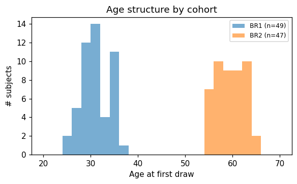

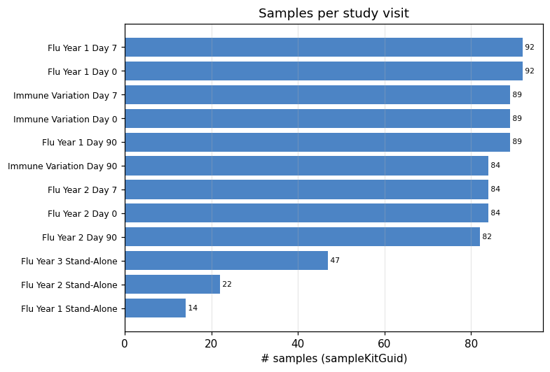

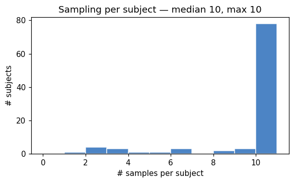

### Subject demographics

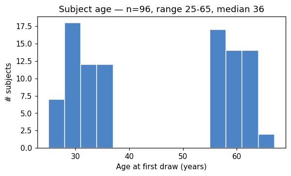

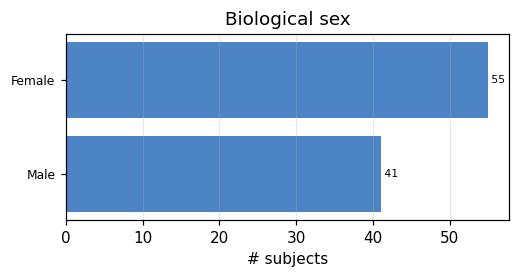

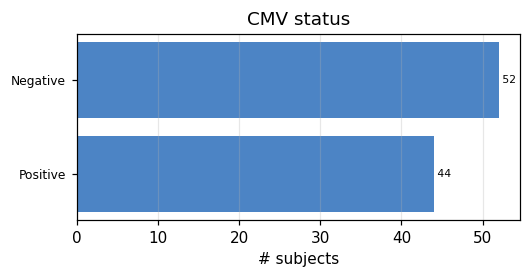

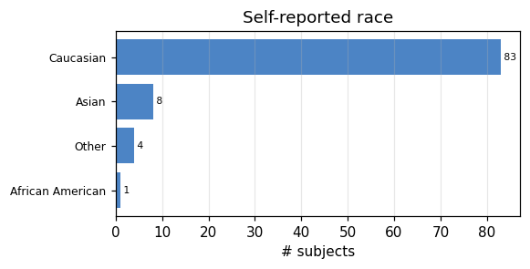

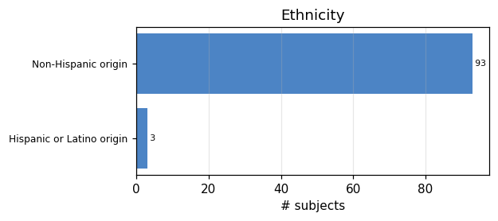

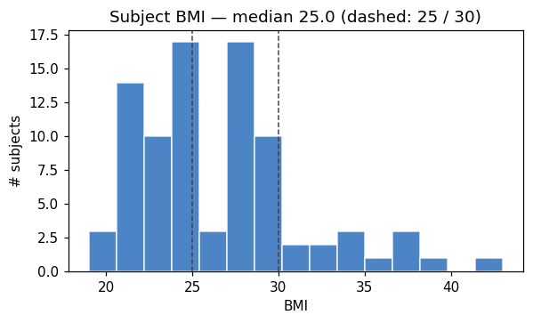

### Cell-type composition

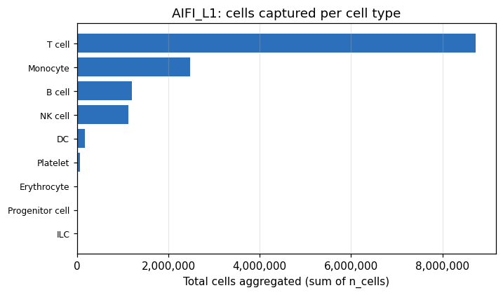

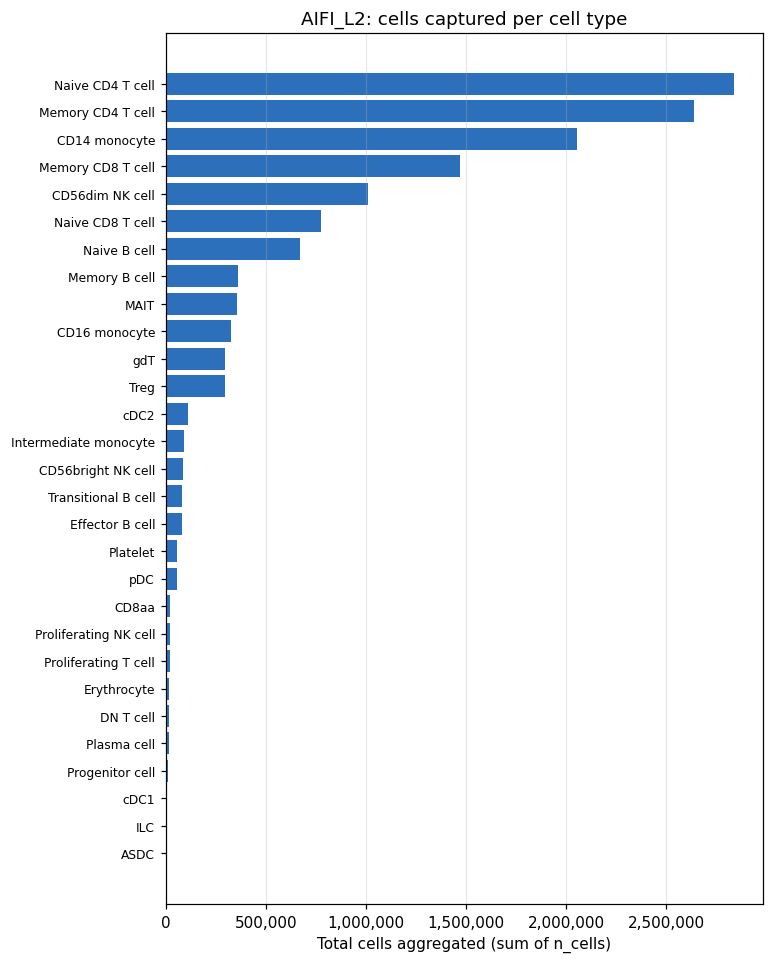

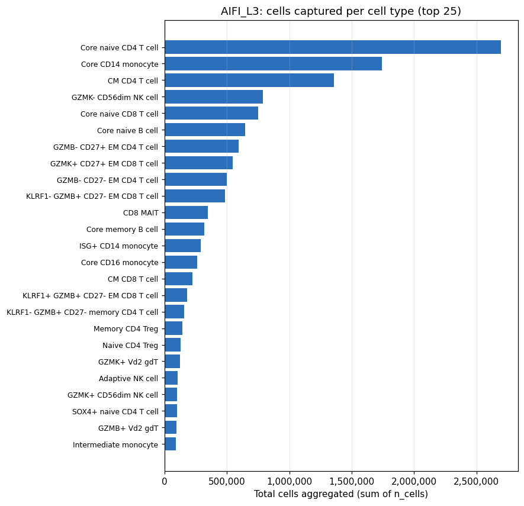

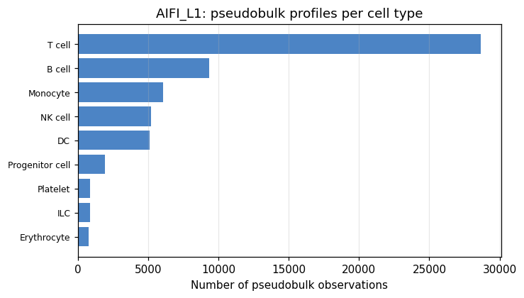

### Pseudobulk depth & QC (n_cells)

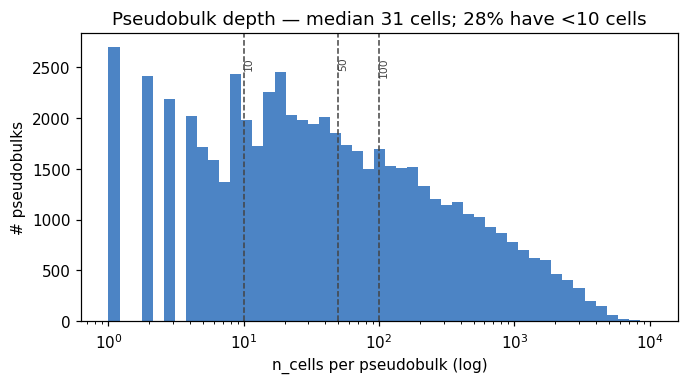

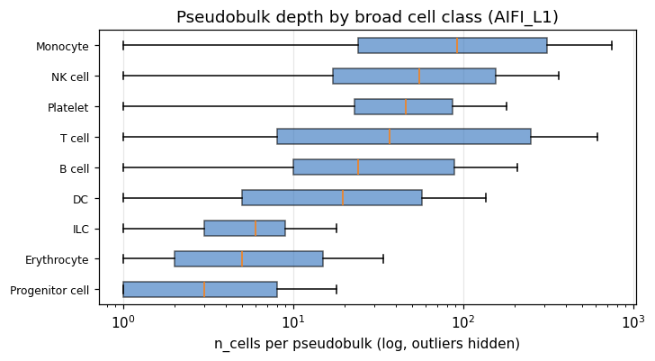

### Gene-level summary

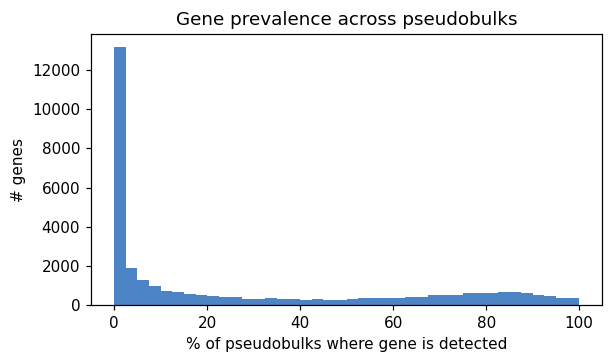

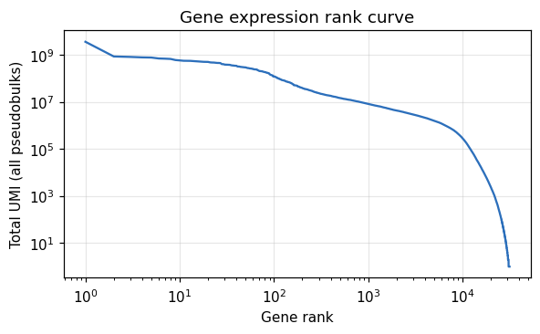

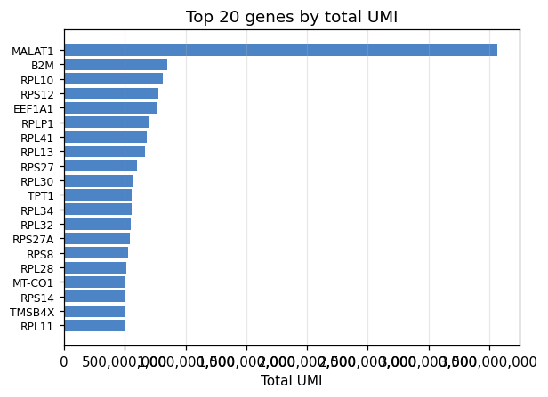

## Immunobiology of Aging

Cross-sectional scRNA-seq across a wide adult age span (cohort SF4, single Immune-Variation Day-0 visit). Pseudobulk aggregated per (AIFI_L3 cell type × sample) with sum / means / detect layers.

15,052

Pseudobulk profiles (rows)

18,082

Genes (features)

17,806

Genes detected (≥1 pb)

50.2%

Matrix density (non-zero)

136,537,944

Non-zero entries

233

Subjects

233

Samples (kits)

17 / 17

Batches / pools

9 / 28 / 70

Cell types L1 / L2 / L3

40–89 (med 58)

Age range (subjects)

### Study design & cohort

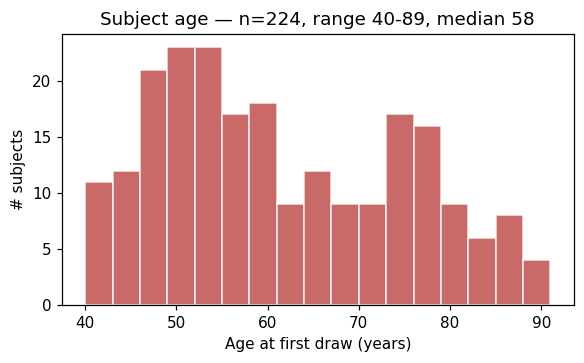

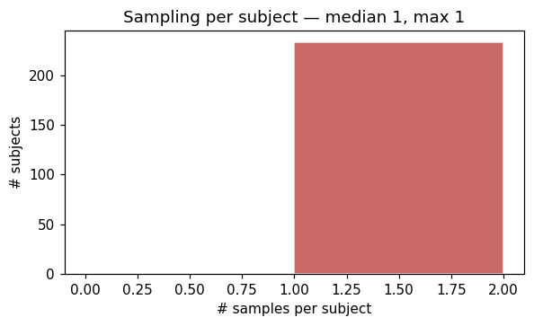

### Subject demographics

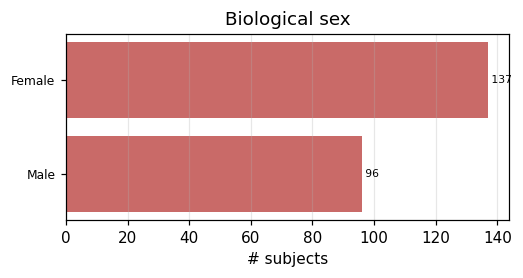

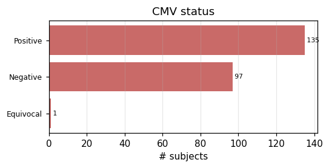

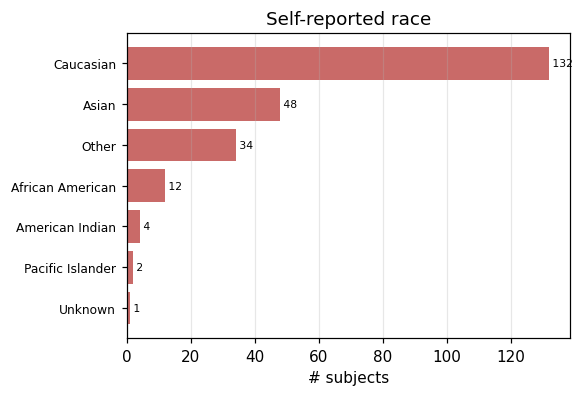

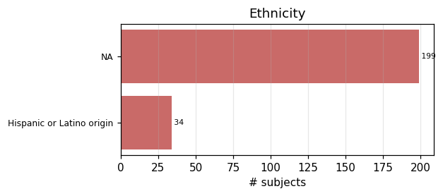

### Cell-type composition

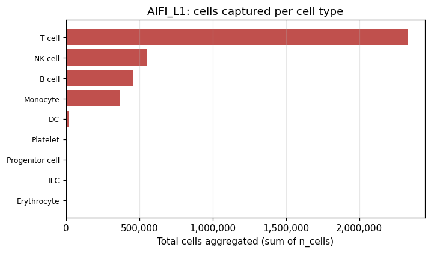

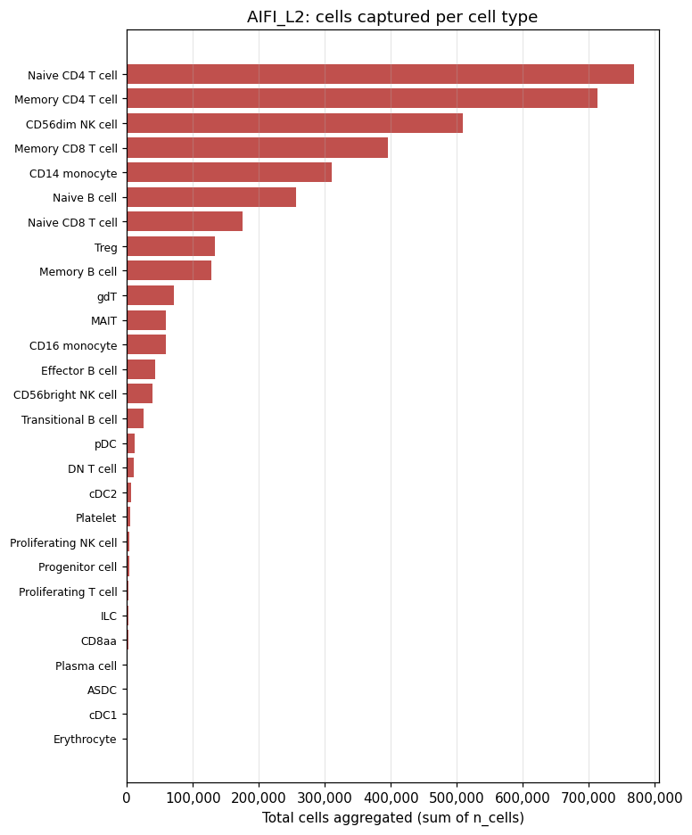

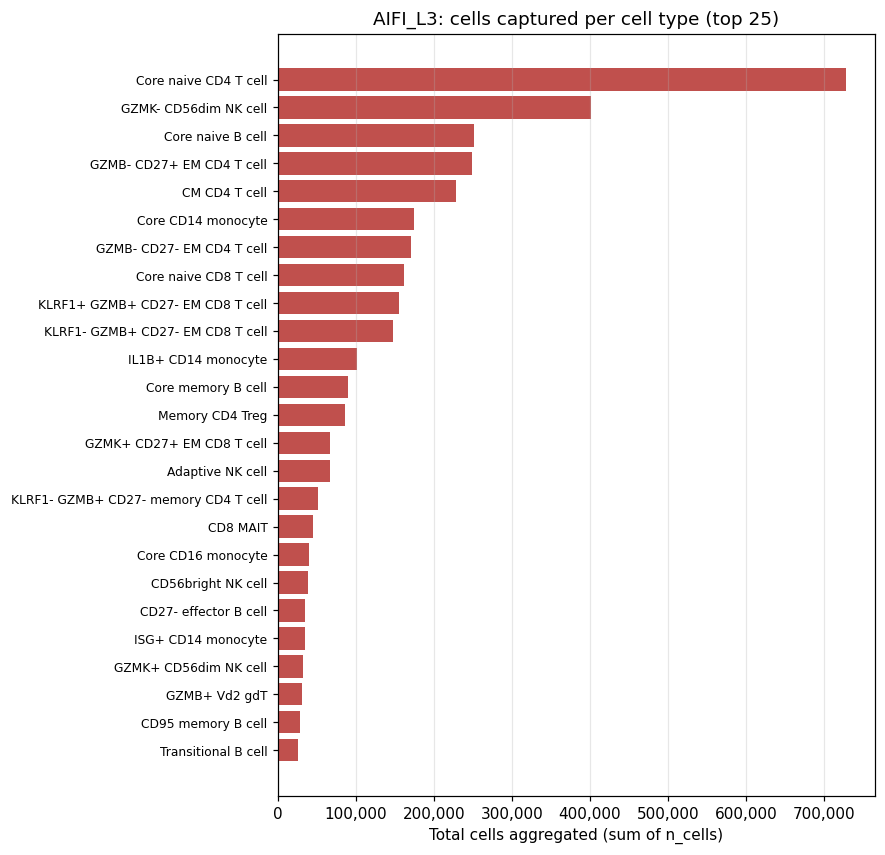

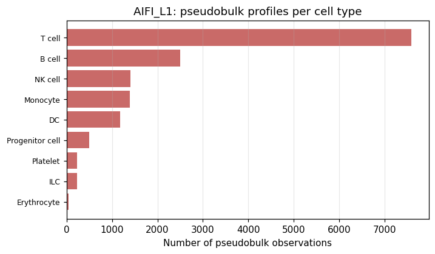

### Pseudobulk depth & QC (n_cells)

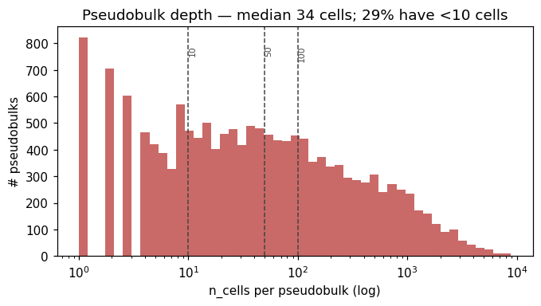

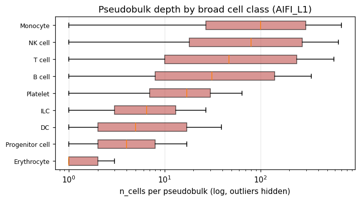

### Gene-level summary

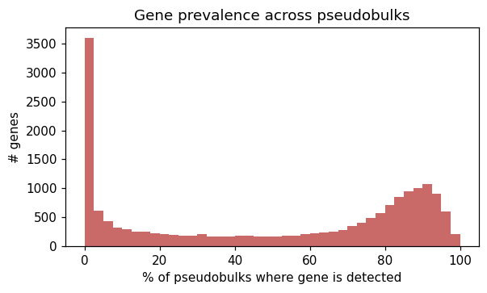

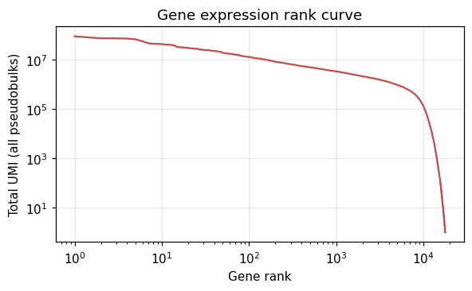

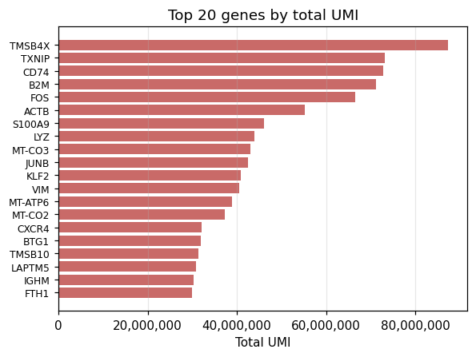

## Cross-dataset comparison

| Metric | Sound Life | Immunobiology of Aging |
| --- | --- | --- |
| Design | Longitudinal (12 visits, flu-vaccine) | Cross-sectional (1 visit) |
| Pseudobulk rows | 58,816 | 15,052 |
| Subjects | 96 | 233 |
| Samples | 868 | 233 |
| Genes | 33,538 | 18,082 |
| Matrix density | 28.1% | 50.2% |
| Age range (yr) | 25–65 | 40–89 |
| Cell types (L3) | 71 | 70 |

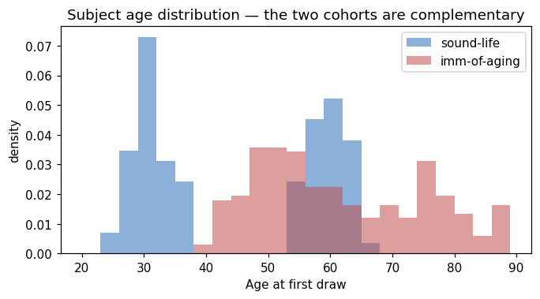